# How My Flatmates Cook: A Visual Data Story

## What meals were recorded?

This visual data story explores meals made by three flatmates over a short observation period. The data includes who made each meal, when it was made, how many fruits or vegetables were used, what cooking method was used, whether a recipe was followed, and how appealing the meal seemed.

The goal is to explore whether cooking choices and meal ingredients are connected to meal appeal.

## Which cooking methods seemed most appealing?

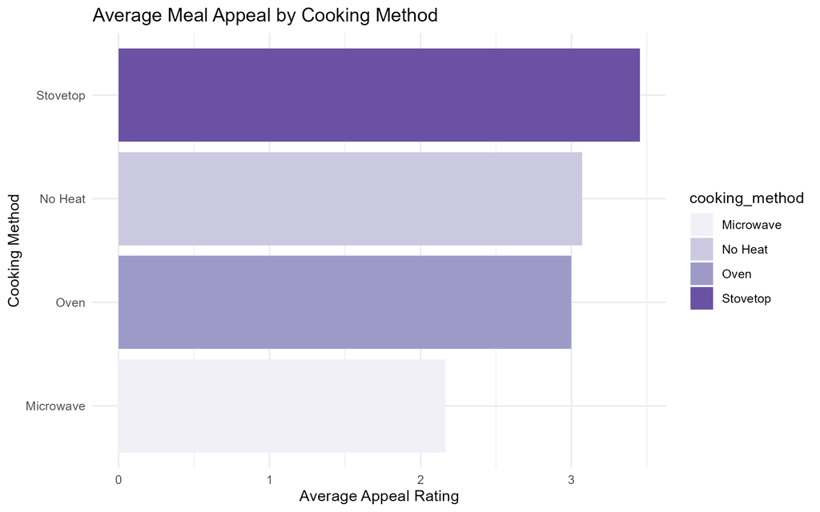

A horizontal bar chart comparing average appeal ratings between cooking methods.

This graph compares the average appeal rating for meals made using different cooking methods. This helps show whether some cooking methods tended to be linked with more appealing meals.

## Did meal logging change over time?

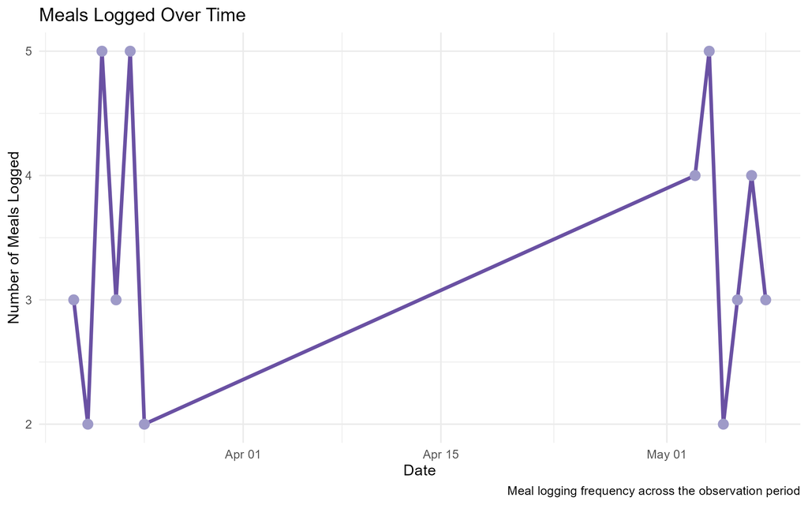

A line graph showing the number of meals logged on each date across the observation period.

This graph uses the timestamp from the original data. It shows how many meals were recorded on each date, which helps reveal patterns in when the data was collected. (I’ts also kind of funny because it shows the gap between data collection for Project2 and 4)

## Are meals with more fruits and vegetables more appealing?

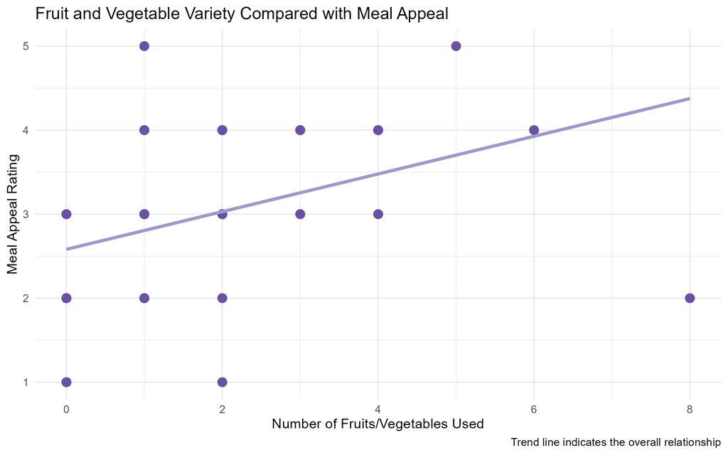

A scatterplot comparing the number of fruits and vegetables used with meal appeal ratings. A trend line shows the overall relationship.

This graph compares fruit and vegetable variety with meal appeal. The trend line helps show whether meals with more fruits and vegetables generally received higher appeal ratings.

## What does the data suggest?

Overall, this data story suggests that meal appeal may be influenced by both ingredients and cooking method. Meals with more fruit and vegetable variety may appear more appealing, and some cooking methods may be associated with higher average appeal ratings.

However, the dataset is quite small, so these patterns should be treated as observations rather than strong conclusions.